# Vorgehensmodelle in der Softwareentwicklung

Wasserfallmodell, V-Modell, Spiralmodell

## Theorie und Praxis …

[figure not shown]

[figure not shown]

Quelle: memecenter.com

### Vorgehensmodelle in der Softwareentwicklung

- Wasserfall-Modell
- V-Modell
- Spiral-Modell

## Der “Oldie”: Das Wasserfall-Modell

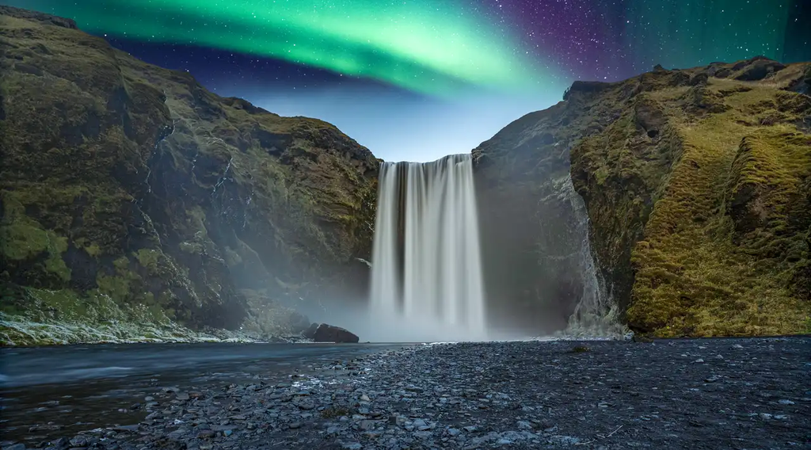

Skógafoss in Island

Quelle: GettyImages / dertour.de

## Wasserfall-Modell: Phasenbeschreibung

| Phase |
| --- |
| 1. Anforderungs- analyse |
| 2. Entwurf |
| 3. Implementierung |
| 4. Test |
| 5. Einführung |
| 6. Wartung |

| Beschreibung |
| --- |
| Anforderungen sammeln |
| Systemarchitektur festlegen |
| Programmierung |
| Qualitätssicherung |
| Deployment beim Kunden |
| Fehlerbehebung, Update |

| Ergebnis |
| --- |
| Lastenheft |
| Pflichtenheft, Architektur |
| Quellcode |
| Testberichte |
| Produktivsystem |
| Patches, neue Versionen |

## Wasserfall-Modell: Geschichte, Einsatz

- Bereits 1956 von **Herbert D. Benington** beschrieben
- Vortrag 1983 neu aufgelegt
- Beschreibung 1970 von **Winston W. Royce**  
  (ohne Bezeichnung Wasserfall)
- Begriff “Wasserfallmodell” später von **Barry Boehm** geprägt
- Geeignet für Projekte mit **stabilen, klar definierten Anforderungen** und **regulatorischen Vorgaben**
- Beispiele: Medizintechnik, Pharmazie, Maschinenbau

## Wasserfall-Modell: Vorteile

- Phasen klar abgegrenzt
- Einfache Möglichkeiten der Planung und Kontrolle
- Kosten und Umfang klar abschätzbar
- ACHTUNG: Wenn Anforderungen stabil bleiben!

## Gescheitertes Wasserfall-Projekt: FBI

- Geheimdienst **FBI**: United States Federal Bureau of Investigation
- Projekt: **Virtual Case File (VCF)**, 2000 - 2005,  
  sollte völlig veraltetes Fallmanagement-System ersetzen
- Kosten: ca. 170 Millionen US-Dollar
- Ergebnis: Projekt abgebrochen, nicht nutzbar

### Gründe

- Wiederholte Veränderungen und Erweiterungen der Anforderungen
- Versuch einer plötzlichen, vollständigen Systemumschaltung ohne Übergangsphase
- Zu starres Projektmanagement; mangelhafte Kommunikation
- **Klassisches Wasserfall-Problem!**

## Wasserfall-Modell: Nachteile

- Klare Abgrenzung der Phasen in komplexen Projekten oft unrealistisch
- Fehler werden oft erst am Ende erkannt
- Geringe Flexibilität durch strikten Ablauf

## Wasserfall-Modell: Frage

Was sind die Phasen des klassischen Wasserfallmodells in der Softwareentwicklung?

**A** Sprint Planning, Daily Standup, Sprint Review und Retrospektive - iterativ in Zyklen  
**B** Inception, Elaboration, Construction, Transition - inkrementell mit Meilensteinen  
**C** Analyse, Design, Implementierung, Test, Wartung - sequentiell ohne Rücksprünge  
**D** Idee, Prototyp, Markteinführung und Skalierung - phasenweise mit Feedback-Schleifen

Richtig ist **C**.

Wasserfallmodell: Lineare Phasen; jede abgeschlossen, bevor nächste beginnt.  
Vorteile: Klare Struktur, Dokumentation.  
Nachteile: Unflexibel bei Änderungen, Fehler spät erkannt. Heute oft durch agile Methoden ersetzt.

## Das V-Modell

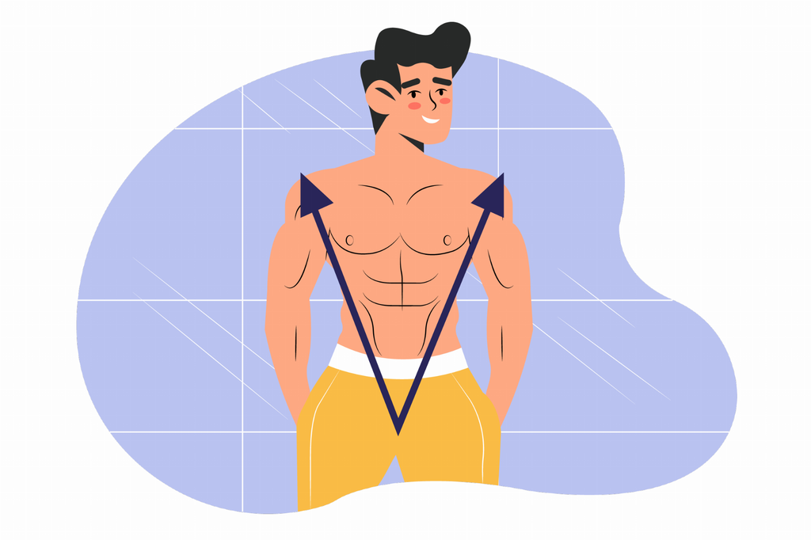

Quelle: alphaprogression.com

## Das V-Modell grafisch

Das **V-Modell** erweitert das Wasserfall-Modell um eine Teststrategie:  
Jeder **Entwicklungsphase** steht eine **Testphase** gegenüber.

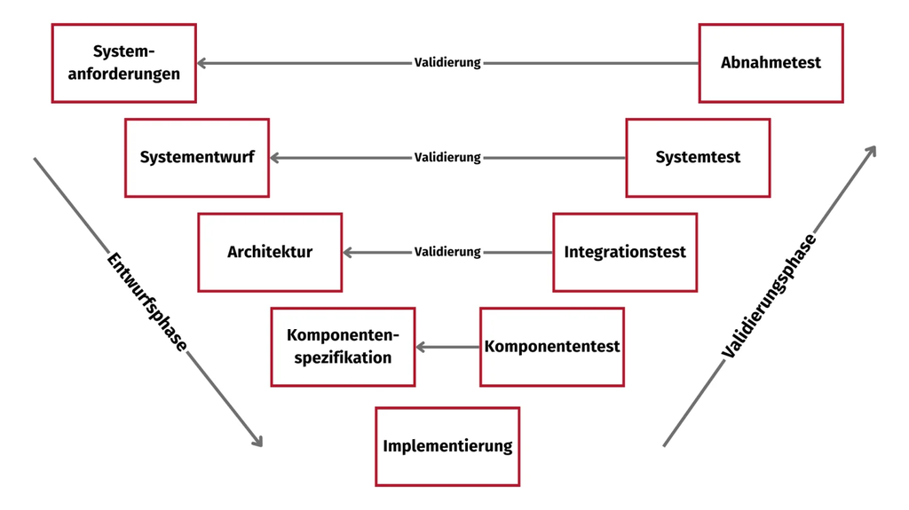

Testphase:

Validierung Verifikation

Quelle: iapm.net

## V-Modell: Geschichte, Einsatz

- Vorgeschlagen von **Barry Boehm** 1979
- Erweiterung des Wasserfall-Modells
- Verwendung auch bei der Entwicklung  
  mechatronischer Systeme
- Geeignet für **sicherheitskritische Systeme** mit klaren, stabilen Anforderungen, hohem Dokumentationsbedarf und verpflichtenden Prüf- und Abnahmeprozessen
- Beispiele: Zugleitsystem, medizinisches Diagnosesystem

## V-Modell: Vorteile

- Klare Struktur, definierter Ablauf
- Klare Zuordnung von Anforderungen und Tests
- Gute Fehlererkennung durch Testphasen
- Gute Nachvollziehbarkeit und Dokumentation

## Problematisches V-Modell: Bundeswehr

- **HERKULES**-Projekt zur Standardisierung und Modernisierung der IT
- Laufzeit 2006 - 2016; Kosten: über 7 Milliarden Euro
- Ergebnis: Systeme z. T. nicht nutzbar; z. T. technisch korrekt, aber sinnlos;  
  z. T. vor der Abnahme schon veraltet
- Projekt umgebaut, neu verhandelt; als “teilweise erfolgreich” deklariert

### Gründe

- Starre Anforderungen: tausende Seiten, während sich IT-Landschaft schnell veränderte (Smartphones, Cloud, Cyber-Bedrohungen)
- Späte Tests; Probleme erst am Ende sichtbar
- Dokumentationslast: “Papier statt Produkt”
- Geringe Flexibilität; V-Modell schwierig bei riesigen Projekten

## V-Modell: Nachteile

- Hoher Aufwand für Dokumentation
- Hohe Abhängigkeit von Testaktivitäten
- Geringe Flexibilität durch fest vorgegebene Phasen
- Annahme: Alle Anforderungen von Anfang an vollständig und korrekt erfasst  
  In der Praxis oft nicht der Fall!
- Mehr Flexibilität durch wiederholte Durchläufe  
  (“Mini-Vs”)? Enorm aufwändig

## V-Modell: Frage

Im V-Modell steht jeder Entwicklungsphase auf der linken Seite eine entsprechende Testphase auf der rechten Seite gegenüber. Welche Testphase korrespondiert mit der Phase Architektur?

**A** Abnahmetest  
**B** Komponententest  
**C** Integrationstest  
**D** Systemtest

Richtig ist **C**.  
Der **Architektur** ist der **Integrationstest** zugeordnet.  
Arbeiten die Module zusammen?  
Funktioniert der Datenaustausch zwischen den Komponenten?

## Verifikation vs. Validierung

| Begriff |
| --- |
| Verifikation |
| Validierung |

| Frage |
| --- |
| Bauen wir das Produkt richtig? |
| Bauen wir das richtige Produkt? |

| Beispiel |
| --- |
| Code-Review, Unit-Test |
| Abnahmetest mit Kunde |

## Das Spiral-Modell

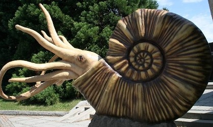

Rekonstruierter Riesen-Ammonit

Quelle: bio-schmidhol.ch

## Spiral-Modell: Grundidee

1986 von **Barry Boehm** beschrieben

Iterativ-inkrementelles Modell

- Iterativ: Produkt wird in mehreren Durchläufen verbessert
- Inkrementell: Produkt wird in Teilen (=Inkrementen) geliefert

## Spiral-Modell: Phasenbeschreibung

Kombination aus **iterativem Vorgehen** und **Risiko-Analyse**

| Schritt |
| --- |
| 1. Ziele festlegen |
| 2. Risiken analysieren |
| 3. Entwicklung |
| 4. Bewertung |

| Beschreibung |
| --- |
| Was soll diese Iteration erreichen? |
| Welche Risiken gibt es? Prototypen bauen |
| Implementierung dieser Iteration inkl. Tests |
| Review mit Stakeholdern Planung nächste Iteration |

## Spiral-Modell grafisch

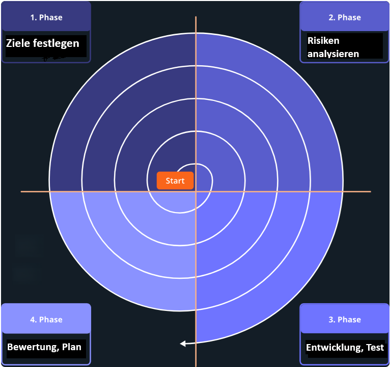

Quelle: simpleclub.com / eigene Bearbeitung

## Spiral-Modell: Vorteile

- Gute Kontrolle über Kosten, Ressourcen, Qualität,  
  v. a. durch zentralen Stellenwert der **Risikoanalyse**
- Gute Abstimmung zwischen Design und technischen Anforderungen
- Frühe, fortlaufende Einbindung von Auftraggebern und Anwendern
- Geeignet für neuartige technische Umgebungen,  
  wenn Erfahrungswerte fehlen;  
  Projekte mit hohen **technischen Risiken**; unklare Anforderungen; wenn **Prototypen** benötigt werden
- Beispiele: Autonomes Fahrassistenzsystem;  
  Satelliten-Kommunikationssoftware

## Gescheitertes Softwareprojekt: US-Luftfahrtbehörde

- US-Luftfahrtbehörde FAA (*Federal Aviation Administration*) wollte  
  **AAS = Advanced Automation System** entwickeln
- Laufzeit 1981 - 1994; Kosten > 2,6 Milliarden US-Dollar
- Ergebnis: Abbruch; stattdessen inkrementell gesteuerte Teilprojekte

### Gründe

- Nicht als Spiralmodell konzipiert, aber z. T. so gehandhabt
- Ständige Änderungen an Anforderungen: Endlosschleife (*Loop of Death*)
- Meilensteine ignoriert, Tests aufgeschoben
- Unrealistische Verfügbarkeit (< 3s Ausfallzeit/Jahr);  
  Risikomanagement hätte das früh entschärfen müssen

## Spiral-Modell: Nachteile

- Hoher Management-Aufwand
- Viele Entscheidungen erforderlich -> Verzögerungen
- Setzt Wissen über Risikoanalyse und Risikomanagement voraus;  
  in der Praxis oft begrenzt!
- Ungeeignet für kleinere Projekte mit geringem Risiko

## Spiral-Modell: Problematische Darstellung (1)

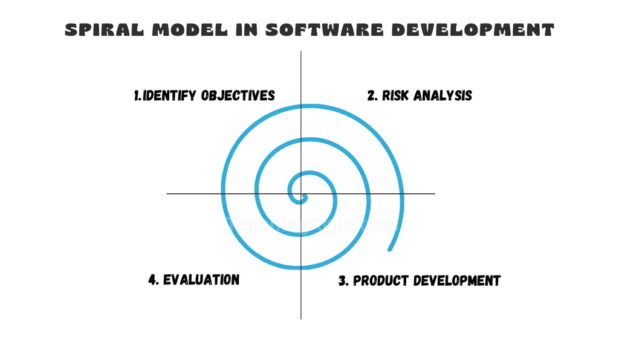

- Wo beginnt die Spirale?
- Welcher Schritt ist der zweite?
- Wo endet die Spirale?

## Spiral-Modell: Problematische Darstellung (2)

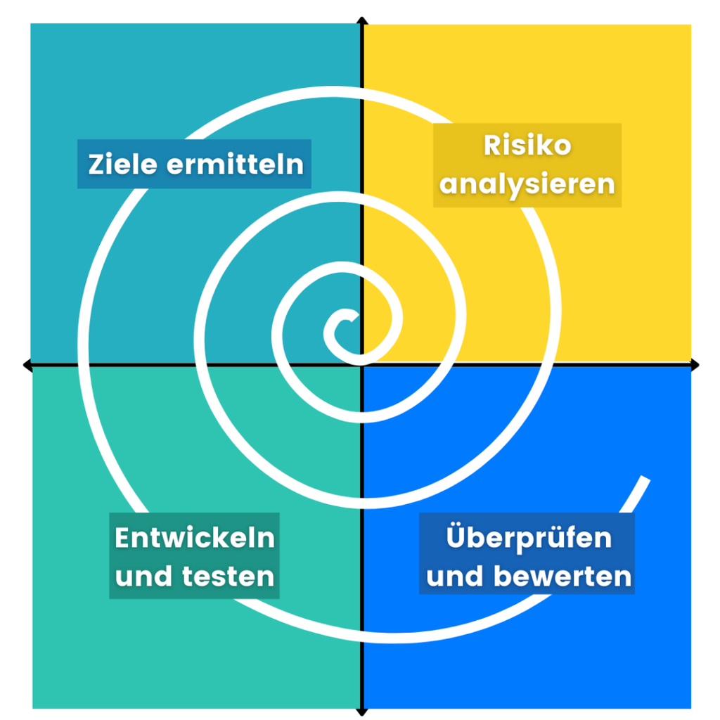

- In welcher Reihenfolge sind die Quadranten angeordnet?
- Was ist die erste, zweite und dritte Phase zu Beginn (innen)?
- In welcher Richtung verläuft die Spirale  
  (-> Uhr)?

## Vergleich der drei Modelle

| **Modell** |
| --- |
| Wasserfall |
| V-Modell |
| Spiralmodell |

| **Geeignet für?** |
| --- |
| Stabile Anforderungen |
| Sicherheitskritische Systeme |
| Große, risikoreiche Projekte |

| **Flexibilität** |
| --- |
| Gering |
| Gering |
| Mittel |

| Risiko |
| --- |
| Hoch bei Änderungen |
| Mittel (frühe Tests) |
| Gering (Risikoanalyse) |

## Gruppenarbeit

Vergleichen Sie die Vorgehensmodelle  
**Wasserfallmodell, V-Modell, Spiralmodell**.

Nennen Sie für jedes Modell:

- 2 Vorteile
- 2 Nachteile und
- ein geeignetes Projektszenario.

## V-Modell, detaillierter

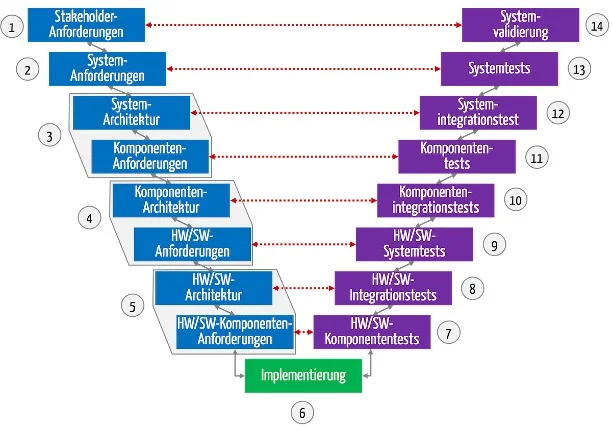

Planung und Spezifikation Implementierung Verifizierung, Validierung

Quelle: johner-institut.de

## Spiral-Modell, detaillierter

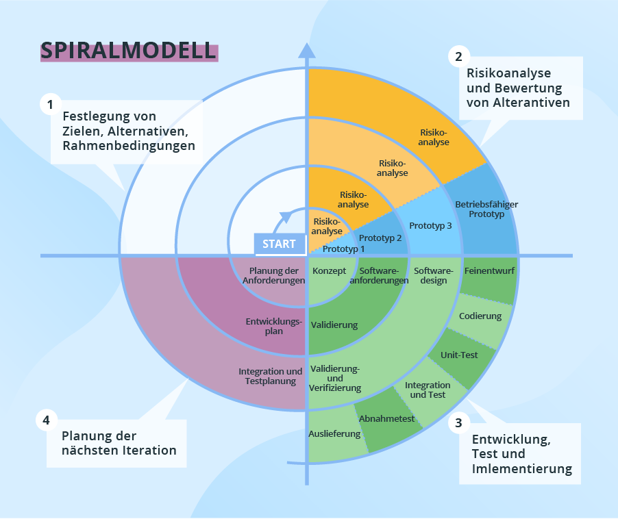

Quelle: scnsoft.de

## Ausblick

Oft mehr Flexibilität benötigt: **Agile Methoden**

- Scrum
- Kanban
- Extreme Programming (XP)

Iterativ, inkrementell, in kurzen Zyklen

Viel Eigenverantwortung für die Teams

## Frage zu Wasserfallmodell (1)

In welcher Situation ist das **Wasserfallmodell** gegenüber **agilem Vorgehen** besonders geeignet?

**A** Bei innovativen Projekten mit häufig wechselnden Anforderungen und hoher Unsicherheit  
**B** Bei Projekten mit stabilen, klar definierten Anforderungen und regulatorischen Vorgaben  
**C** Bei Start-up-Projekten, die keine feste Deadline und kein fixes Budget haben  
**D** Bei Projekten mit hoher Unsicherheit und noch nicht klar definierten Zielen

Richtig ist **B**.

Das Wasserfallmodell eignet sich besonders für Projekte mit **stabilen Anforderungen**, z. B. in **regulierten Branchen** (Medizintechnik, Luftfahrt). Dort müssen alle Anforderungen vorab dokumentiert und genehmigt werden. Bei häufig wechselnden Anforderungen sind agile Methoden besser geeignet.

## Frage zu Wasserfallmodell (2)

Welcher grundlegende Unterschied besteht zwischen dem **Wasserfallmodell** und **agilen Vorgehensweisen**?

**A** Agile Methoden erfordern keinerlei Dokumentation, das Wasserfallmodell hingegen schon  
**B** Das Wasserfallmodell ist grundsätzlich schneller als agile Methoden  
**C** Das Wasserfallmodell wird nur für kleine Projekte eingesetzt, agile nur für große  
**D** Das Wasserfallmodell durchläuft die Phasen sequenziell und linear, während agile Methoden iterativ und inkrementell in kurzen Zyklen arbeiten

Richtig ist **D**. *Hohe Prüfungswahrscheinlichkeit!*

Wasserfallmodell: Phasen (Anforderungen, Entwurf, Implementierung, Test, Betrieb) werden strikt nacheinander durchlaufen. Rückschritte aufwändig. Agile Methoden arbeiten in kurzen Iterationen (z. B. Sprints), liefern regelmäßig lauffähige Software-Inkremente. Dadurch frühes Feedback und flexible Anpassungen an geänderte Anforderungen.

## Frage V-Modell vs. Wasserfallmodell

Worin liegt der Vorteil des V-Modells gegenüber dem Wasserfallmodell?

Zu jeder **Entwicklungsphase** wird **gleichzeitig** der passende **Testfall** definiert — Fehler werden systematischer und früher erkannt.

Es ist in Behörden und regulierten Branchen verbreitet.

## Vielen Dank!

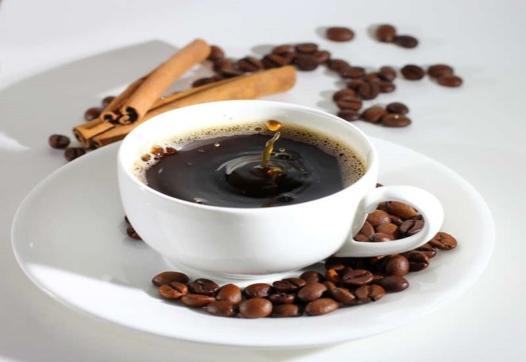

**Viel Erfolg bei allem!**

Zurück zur Übersicht LF5